# Introduction to Advanced Modelling: Feature Engineering

Or how to prepare an informative input from raw data

Advanced Modelling, Master in Computational Social Science

UC3M, 2025–2026

## Introduction

Machine learning relies not only on advanced algorithms but also on high-quality data. The process of transforming raw data into valuable predictors, known as **feature engineering**, often determines how successful a machine-learning model will be.

> Coming up with features is difficult, time-consuming, requires expert knowledge. ‘Applied machine learning’ is basically feature engineering — Prof. Andrew Ng.

**Machine-learning steps:**

1. Prepare the input: collect, clean, transform, filter, aggregate, merge, verify, etc.
2. Prepare a model: build, estimate, validate, predict, etc.
3. Prepare the output: communicate the results, interpret, publish, etc.

Feature engineering primarily addresses Step 1: converting raw data into meaningful inputs.

In many cases, half the success of a machine-learning project depends on effectively engineered features, while the other half depends on the choice of model.

> Feature engineering is the process of transforming raw data into features that better represent the underlying problem to the predictive models, resulting in improved model accuracy on unseen data. — Dr. Jason Brownlee

In the our **Topic 1** slides, we introduced data science and ML concepts, such as types of learning, model validation and so on, mostly focused on the Step 2, preparing the model. This notebook is mostly about **Step 1 (prepare the input)**: how to build a useful set of predictors `X` from messy, real-world sources. Near the end we will also fit a few models (starting with linear regression, and then a short preview of a tree-based model) just to illustrate what would be the types of tasks we will do in the rest of the course.

## What’s a feature?

In machine learning, a **feature** is a measurable attribute or variable, corresponding to a column in the dataset, that helps a model make predictions. Broadly, features fall into two categories:

1. Raw features: Directly obtained from the dataset without additional manipulation.
2. Derived features: Created through further processing of existing attributes.

## Data cleaning

Before feature engineering, we must ensure that the data is reliable and consistent. Data cleaning often involves:

- Removing duplicate or irrelevant observations
- Correcting typos or errors
- Handling outliers (deciding whether to remove or transform them)
- Dealing with missing values (e.g., through imputation or deletion)

## Feature extraction

With cleaned data in hand, we can begin **feature extraction**, the process of creating or refining features. Common tasks include:

- Combining multiple data sources: Merging external data (e.g., census or weather data) to enrich your dataset.
- Smoothing or filtering: Aggregating hourly data to monthly, or otherwise reducing noise.
- Discretizing variables: Grouping continuous data into categories (e.g., “Young” and “Old” from an age variable).
- Normalizing or scaling: Converting variables to a common scale or distribution.
- Combining variables: For example, creating population density from population and area, or using techniques like PCA for dimensionality reduction.
- Selecting features: From a large set of potential variables, identifying the most relevant ones to improve model performance and prevent overfitting.
- Utilizing deep learning: Modern neural networks can learn useful features automatically (particularly in domains like images, text, and video), reducing the need for manual feature engineering.

## Today’s session

**Objective:** practice feature extraction and data cleaning to learn about some socio-economic variables in Spain, using election participation as the running example.

We will frame this as a supervised learning *regression* task:

- **Unit of analysis:** census section (*sección censal*)
- **Target (`Y`):** participation rate (votes / census, continuous)
- **Predictors (`X`):** income, demographics, and (optionally) geography

Organization:

1. Get variables from many sources
2. Obtain information through feature engineering
3. Make cool graphs

We will use R, hence start by loading some packages:

```r
library(tidyverse)
library(leaflet)
library(sf)
library(readxl)
library(stringr)

# And set a seed for reproducibility
set.seed(42)
```

## First data source

From Ministerio del Interior (Spain), we have data at very low level (poll station) about elections.

Download first data from Aula Global and unzip the data folder it on the same directory as this notebook (You can do this with `unzip("data.zip", exdir = "./")`, but you need to run it stting the working directory where you have your `data.zip` file). The data can also be obtained from [Ministerio del Interior](https://infoelectoral.interior.gob.es/es/elecciones-celebradas/area-de-descargas/) (last available elections: July 2023).

We will use the file “09022307.DAT” that contains information about participation by poll station. See “Ficheros.doc” for more details.

Note the name of the file (09022307.DAT) is informative: poll level (09) + national elections (02) + year (23) + month (07)

Read now data file and assign names

```r
participacion <- read.fwf("data/09022307.DAT",
                          widths=c(2,4,2,1,
                                   2,2,3,2,4,1,
                                   7,7,7,7,7,7,7,7,7,7,7,
                                   1),
                          colClasses=c(rep("numeric",4),
                                       rep("character",6),
                                       rep("numeric",11),
                                       "character"))

colnames(participacion) <- c("tipo","year","month","vuelta","ccaa","provincia","municipio","distrito","seccion","mesa","censo","censo_escrutinio","censo_cere","total_cere","votantes_primer","votantes_segundo","blanco","nulos","votos","afirmativos","negativos","datos_oficiales")
```

Take a look

```r
head(participacion)
```

```
##   tipo year month vuelta ccaa provincia municipio distrito seccion mesa censo
## 1    2 2023     7      1   01        04       001       01    001     A   429
## 2    2 2023     7      1   01        04       001       01    001     B   566
## 3    2 2023     7      1   01        04       002       01    001     A   445
## 4    2 2023     7      1   01        04       002       01    001     B   589
## 5    2 2023     7      1   01        04       003       01    001     U   627
## 6    2 2023     7      1   01        04       003       01    002     A   607
##   censo_escrutinio censo_cere total_cere votantes_primer votantes_segundo
## 1              429          0          0             187              249
## 2              566          0          0             239              315
## 3              445          0          0             193              249
## 4              589          0          0             259              325
## 5              627          0          0             299              388
## 6              607          0          0             279              378
##   blanco nulos votos afirmativos negativos datos_oficiales
## 1      1     2   328           0         0               S
## 2      3     4   409           0         0               S
## 3      1     3   340           0         0               S
## 4      2     3   438           0         0               S
## 5      3     6   469           0         0               S
## 6      6     6   450           0         0               S
```

This is high granularity data: information up to *mesa electoral* (poll station)

Remember, a country is usually divided into administrative areas: states/CCAA, then regions/provinces, then towns/municipalities, then census sections, then poll stations, etc.

Now we are ready to start with our **feature engineering**:

Focus on national elections:

```r
participacion = participacion %>%
  select(ccaa, provincia, municipio, distrito, seccion, censo, votos) %>%
  filter(ccaa<99, provincia<99, municipio<999) # This removes special results such as the total, or voting from other countries
```

**Feature extraction**

Obtain the CUSEC identification for census sections. This will be the common identifier to merge other datasets.

```r
participacion = participacion %>%
  mutate(CUSEC = str_trim(paste0(participacion$provincia,participacion$municipio,participacion$distrito,participacion$seccion)))
```

Take a look:

```r
str(participacion)
```

```
## 'data.frame':    60314 obs. of  8 variables:
##  $ ccaa     : chr  "01" "01" "01" "01" ...
##  $ provincia: chr  "04" "04" "04" "04" ...
##  $ municipio: chr  "001" "001" "002" "002" ...
##  $ distrito : chr  "01" "01" "01" "01" ...
##  $ seccion  : chr  "001 " "001 " "001 " "001 " ...
##  $ censo    : num  429 566 445 589 627 607 691 770 852 643 ...
##  $ votos    : num  328 409 340 438 469 450 499 515 577 400 ...
##  $ CUSEC    : chr  "0400101001" "0400101001" "0400201001" "0400201001" ...
```

```r
head(participacion)
```

```
##   ccaa provincia municipio distrito seccion censo votos      CUSEC
## 1   01        04       001       01    001    429   328 0400101001
## 2   01        04       001       01    001    566   409 0400101001
## 3   01        04       002       01    001    445   340 0400201001
## 4   01        04       002       01    001    589   438 0400201001
## 5   01        04       003       01    001    627   469 0400301001
## 6   01        04       003       01    002    607   450 0400301002
```

There are close to 60,000 poll stations, 36,000 census sections, more than 8,000 municipalities, 52 provinces, and 17+2 CCAA.

### Encoding

Most statistical and machine-learning models require the predictors to be in some sort of numeric encoding. For example, linear regression requires numbers so that it can assign slopes to each predictor.

The most common encoding is to make simple dummy variables: if we have a predictor with $c$ levels, then $c-1$ dummies are needed. In this way, the $X$ matrix is full rank.

Convert char variables into factor ones: this conversion will be used in R models as encoding (creation of dummies)

```r
participacion$ccaa = as.factor(participacion$ccaa)
participacion$provincia = as.factor(participacion$provincia)
```

Take a look at the census by poll station and CCAA:

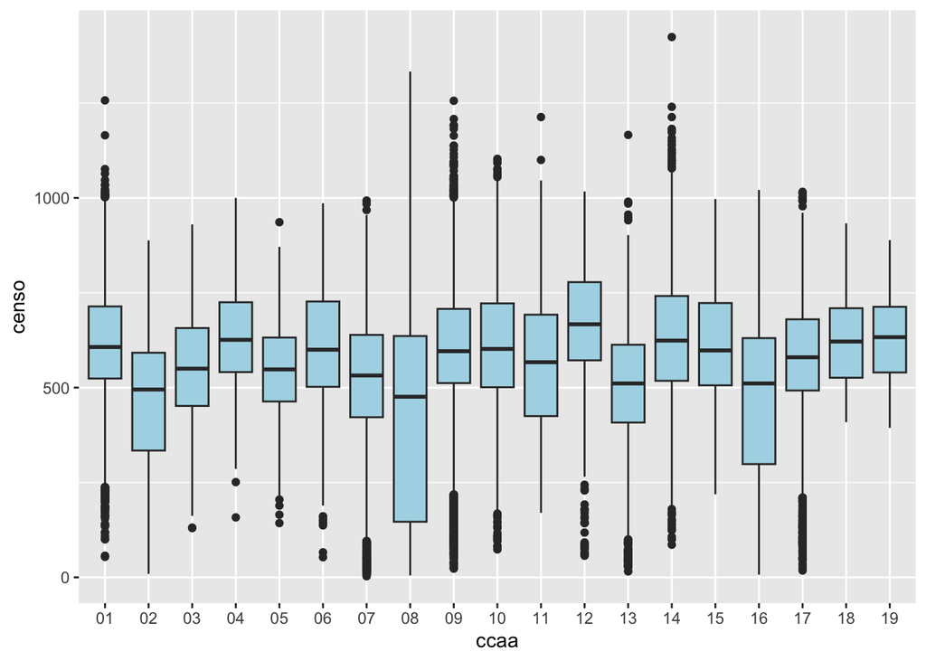

```r
participacion %>% ggplot(aes(x=ccaa,y=censo)) + geom_boxplot(fill="lightblue")
```

Some stations with censo<=10, or censo>=1000: high variability

### Aggregation:

From poll stations to census sections

Then, build our first informative feature: **participation level** (from votes and census).

```r
part.aggr = participacion %>%
  group_by(provincia,municipio,distrito,seccion,CUSEC) %>%
  summarize(total_votos=sum(votos),total_censo=sum(censo)) %>%
  mutate(total_part = total_votos/total_censo)
```

There are more than 36,000 census sections

### Maps

Obtain census limits from INE: https://www.ine.es/ss/Satellite?L=es_ES&c=Page&cid=1259952026632&p=1259952026632&pagename=ProductosYServicios%2FPYSLayout

```r
limits <- read_sf("data/LimitesCensoINE/SECC_CE_20200101.shp") %>%
  # just in case we want to filter by CCAA
  # filter(NCA == "Comunidad de Madrid") %>%
  sf::st_transform('+proj=longlat +datum=WGS84')
```

Then, merge geographic information with participation level data. Note we need a common identifier.

```r
datos.mapa <- merge(limits,part.aggr,by="CUSEC")
```

Then, we can plot in a map the participation levels by census section (take care: this is a very expensive map and you should run it interactively, so its not compiled when knitting the Rmd file)

```r
pal <- colorQuantile("Blues", part.aggr$total_part, na.color="white")

labels = paste(datos.mapa$NMUN, "<br>", "Sección censal: ", datos.mapa$CUSEC, "<br>", "Participación: ", round(datos.mapa$total_part*100,2), "%") %>%
  lapply(htmltools::HTML)


leaflet(datos.mapa) %>%
  #addMapboxTiles(style_id = "streets-v11",
  #               username = "mapbox") %>%
  addProviderTiles(providers$CartoDB.Positron) %>%
  setView(lng = -3.69,
          lat = 40.42,
          zoom = 7) %>%
  addPolygons(fillColor = ~ pal(total_part),fillOpacity = 0.6,color = "white",weight = .5,
              opacity = 1, smoothFactor = 0.2,stroke=T,
              label = ~ labels,
              highlightOptions = highlightOptions(color = "black",
                                                  weight = 2,
                                                  bringToFront = F))
```

### Merge more information

Is the income a driver of participation?

Let’s download the average net-income per capita from INE: https://www.ine.es/jaxiT3/Tabla.htm?t=31097

To preserve confidentiality, INE only provides incomes between percentiles 0.1% and 99.5%

Let’s focus our analysis on just Madrid (all census sections, more than 4,400): https://www.ine.es/jaxiT3/Tabla.htm?t=31097&L=0

```r
renta = read_excel('data/RentaMadrid31097_2022.xlsx', skip=8, col_names = F, trim_ws=T,col_types=c("text", "numeric"))
renta$CUSEC = substr(renta$...1, 1, 10)
renta$rentaMedia = renta$...2
renta = renta %>% select(CUSEC, rentaMedia)
```

Merge income with participation data:

```r
datos.madrid = filter(datos.mapa, provincia == 28) # just Madrid
datos.madrid <- merge(datos.madrid, renta, by="CUSEC")
```

Is the income a driver of participation?

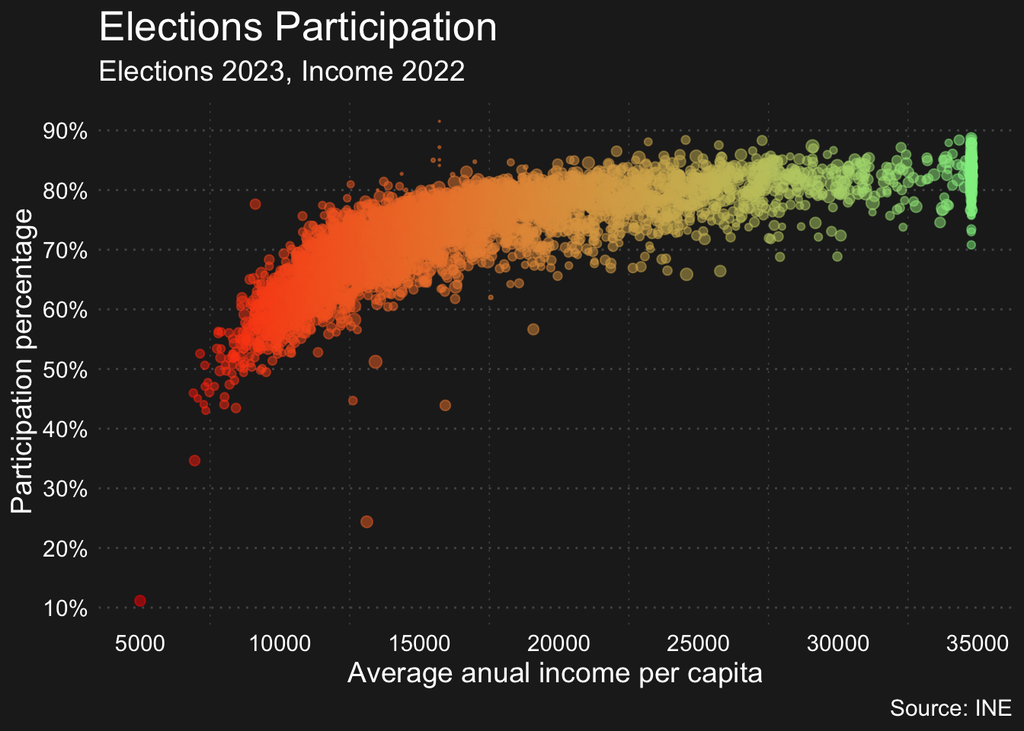

```r
datos.madrid %>%
  ggplot(aes(x = rentaMedia, y = total_part, label=NMUN, size=total_censo, color=rentaMedia, fill=rentaMedia))  +
  scale_x_continuous(n.breaks = 8) +
  scale_y_continuous(n.breaks = 8,labels = scales::percent) +
  geom_point(alpha=0.5) + scale_size(range = c(0, 3)) +
  scale_colour_gradientn(colours = c("red","lightgreen")) +
  labs(title = "Elections Participation", subtitle="Elections 2023, Income 2022", x = "Average anual income per capita", y = "Participation percentage", caption="Source: INE") +
  theme_minimal() +
  theme(plot.background = element_rect(fill='#212121'), text=element_text(size=14,color='#FFFFFF'),
        axis.text = element_text(color='#FFFFFF'), panel.grid.major.y = element_line(color = '#55565B', linetype = "dotted"),panel.grid.major.x = element_blank(),
        panel.grid.minor.y = element_blank(),panel.grid.minor.x = element_line(color = '#55565B', linetype = "dotted"),
        plot.title=element_text(size=20), legend.position="none")
```

There is a clear increasing but non-linear relation

Of course other variables are affecting the participation level

Note this relationship can change between provinces (the shape of the curvature)

### Analytical tools

Let’s make some regression models to understand better the relation

Filter very low and very high incomes to reduce variability

```r
datos.madrid = datos.madrid %>% drop_na(rentaMedia) %>%
  filter(rentaMedia>6000, rentaMedia<31000, total_censo>100)
```

**Train and test splitting**: In the slides we emphasized that we care about **generalization**: we train on one part of the data, and we evaluate on unseen data. In a real project you would typically use cross-validation on the training set for model selection/tuning, and keep the test set for a final evaluation. Here we use a simple split just to compare models.

```r
n = dim(datos.madrid)[1]
n.train = round(0.7*n)
set.seed(123)
ind.train = sample(1:n, n.train, replace = FALSE)
train = datos.madrid[ind.train,]
test = datos.madrid[-ind.train,]

# Define also a function for R^2 on held-out data (see slides: "Regression Metrics: R-squared")
rsq = function(y, yhat) {
  1 - sum((y - yhat)^2) / sum((y - mean(y))^2)
}
```

Try a simple regression:

```r
simple.lm = lm(total_part ~ rentaMedia, train)
simple.lm %>% summary()
```

```
##
## Call:
## lm(formula = total_part ~ rentaMedia, data = train)
##
## Residuals:
##      Min       1Q   Median       3Q      Max
## -0.43868 -0.02930  0.00234  0.03510  0.14101
##
## Coefficients:
##              Estimate Std. Error t value Pr(>|t|)
## (Intercept) 5.368e-01  2.895e-03  185.41   <2e-16 ***
## rentaMedia  1.112e-05  1.722e-07   64.56   <2e-16 ***
## ---
## Signif. codes:  0 '***' 0.001 '**' 0.01 '*' 0.05 '.' 0.1 ' ' 1
##
## Residual standard error: 0.04801 on 2925 degrees of freedom
## Multiple R-squared:  0.5877, Adjusted R-squared:  0.5875
## F-statistic:  4169 on 1 and 2925 DF,  p-value: < 2.2e-16
```

Does it capture well the participation variability?

```r
pred = predict(simple.lm, newdata = test)

c(train_R2 = rsq(train$total_part, predict(simple.lm, newdata = train)),
  test_R2  = rsq(test$total_part, pred))
```

```
##  train_R2   test_R2
## 0.5876551 0.6140851
```

No overfitting, reliable model. But accurate?

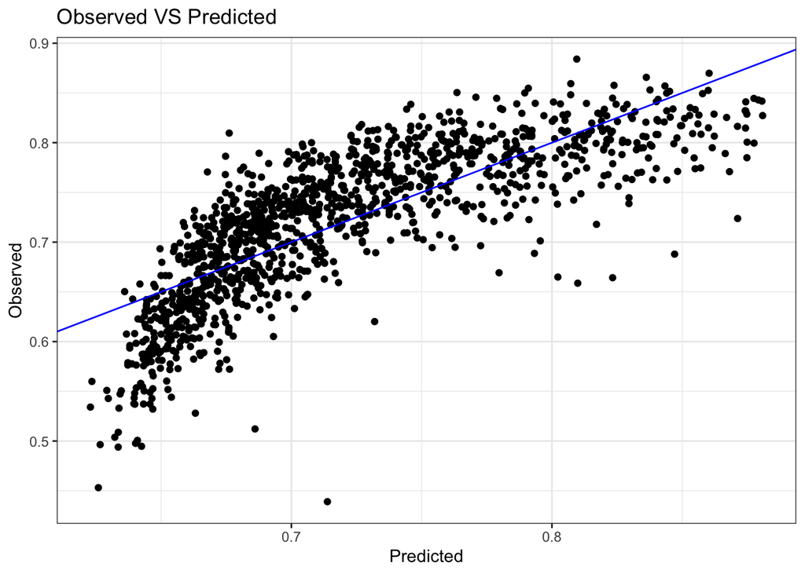

```r
qplot(pred, test$total_part) +
  labs(title="Observed VS Predicted", x="Predicted", y="Observed") +
  geom_abline(intercept = 0, slope = 1, colour = "blue") +
  theme_bw()
```

It is not capturing well the non-linearity (not enough accurate)

Can we capture a non-linearity with a linear model? Yes, if we introduce new variables or features that are non linear transformations.

```r
simple.lm = lm(total_part ~ I(1/rentaMedia), train)
simple.lm %>% summary()
```

```
##
## Call:
## lm(formula = total_part ~ I(1/rentaMedia), data = train)
##
## Residuals:
##      Min       1Q   Median       3Q      Max
## -0.44700 -0.02488  0.00293  0.02788  0.18981
##
## Coefficients:
##                   Estimate Std. Error t value Pr(>|t|)
## (Intercept)      9.292e-01  2.587e-03  359.18   <2e-16 ***
## I(1/rentaMedia) -3.125e+03  3.615e+01  -86.46   <2e-16 ***
## ---
## Signif. codes:  0 '***' 0.001 '**' 0.01 '*' 0.05 '.' 0.1 ' ' 1
##
## Residual standard error: 0.03965 on 2925 degrees of freedom
## Multiple R-squared:  0.7188, Adjusted R-squared:  0.7187
## F-statistic:  7475 on 1 and 2925 DF,  p-value: < 2.2e-16
```

```r
pred = predict(simple.lm, newdata = test)

c(train_R2 = rsq(train$total_part, predict(simple.lm, newdata = train)),
  test_R2  = rsq(test$total_part, pred))
```

```
##  train_R2   test_R2
## 0.7187608 0.7308265
```

Better, and again no overfitting, reliable, and it seems to capture non-linearity.

We can visualize how the model would behave on the test data by creating a sequence of values in the test data range, and plotting the model predictions forming a line over our actual test data observations:

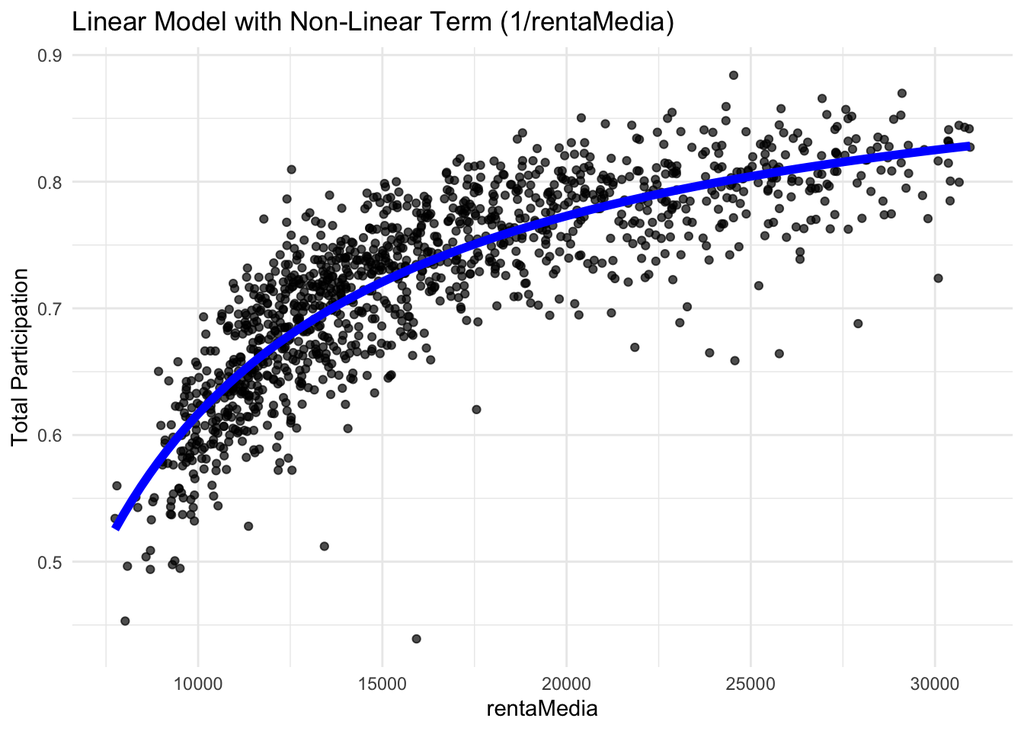

```r
# Create a grid of rentaMedia values spanning the range of the testing set:
renta_seq <- seq(min(test$rentaMedia),
                 max(test$rentaMedia),
                 length.out = 100)

# Build a data frame for predictions in the testing set:
pred_data <- data.frame(rentaMedia = renta_seq)

# Get predicted total_part from the model:
pred_data$predicted_part <- predict(simple.lm, newdata = pred_data)

# Plot the testing set along with the model:
ggplot(test, aes(x = rentaMedia, y = total_part)) +
  geom_point(alpha = 0.7) +
  geom_line(data = pred_data,
            aes(x = rentaMedia, y = predicted_part),
            color = "blue",
            linewidth = 2) +
  labs(title = "Linear Model with Non-Linear Term (1/rentaMedia)",
       x = "rentaMedia",
       y = "Total Participation") +
  theme_minimal()
```

That’s ok, but if we want to improve the accuracy, we could need more variables (or maybe better models!)

### Merge more information

Here we can get more variables for Madrid: https://www.ine.es/jaxiT3/Datos.htm?t=31105

In particular, the mean age, population, and percentage of Spanish people for each census section in Madrid.

```r
demog = read_excel('data/DemograficoMadrid31105.xlsx', skip=8, col_names = F, trim_ws=T,col_types=c("text", "numeric", "numeric", "numeric"))

demog$CUSEC = substr(demog$...1, 1, 10)
demog$EdadMedia = demog$...2
demog$Poblacion = demog$...3
demog$PoblacionEsp = demog$...4
demog = demog %>% select(CUSEC, EdadMedia, Poblacion, PoblacionEsp)

datos.madrid <- merge(datos.madrid, demog, by="CUSEC")
```

```r
head(datos.madrid)
```

```
## Simple feature collection with 6 features and 31 fields
## Geometry type: MULTIPOLYGON
## Dimension:     XY
## Bounding box:  xmin: -4.026818 ymin: 40.20948 xmax: -3.435099 ymax: 40.97279
## Geodetic CRS:  +proj=longlat +datum=WGS84
##        CUSEC CUMUN CSEC CDIS CMUN CPRO CCA   CUDIS CLAU2   NPRO
## 1 2800201001 28002  001   01  002   28  13 2800201 28002 Madrid
## 2 2800201002 28002  002   01  002   28  13 2800201 28002 Madrid
## 3 2800301001 28003  001   01  003   28  13 2800301 28003 Madrid
## 4 2800401001 28004  001   01  004   28  13 2800401 28004 Madrid
## 5 2800401002 28004  002   01  004   28  13 2800401 28004 Madrid
## 6 2800401003 28004  003   01  004   28  13 2800401 28004 Madrid
##                   NCA CNUT0 CNUT1 CNUT2 CNUT3 ESTADO  OBS              NMUN
## 1 Comunidad de Madrid    ES     3     0     0      I <NA>           Ajalvir
## 2 Comunidad de Madrid    ES     3     0     0      I <NA>           Ajalvir
```

[output cut: 25 more lines]

How the other variables are affecting participation? Lets modify our previous graph to contain now the mean percentage of Spanish population as a color gradient and the municipality name where the census section is located as a text label. You can also play with he graph and add the mean age instead of the percentage of Spanish population in the color, or tweak any other variables.

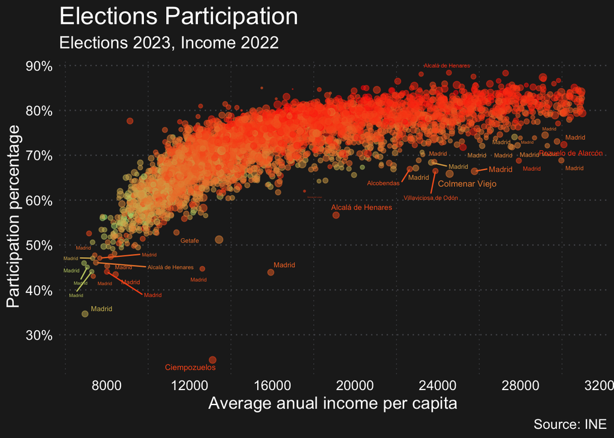

```r
datos.madrid %>%
  ggplot(aes(x = rentaMedia, y = total_part, label=NMUN, size=total_censo, color=PoblacionEsp))  +
  scale_x_continuous(n.breaks = 8) +
  scale_y_continuous(n.breaks = 8,labels = scales::percent) +
  geom_point(alpha=0.5) +  scale_size(range = c(0, 3)) +
  ggrepel::geom_text_repel(max.overlaps = 20) +
  scale_colour_gradientn(colours = c("lightgreen", "red")) +
  labs(title = "Elections Participation", subtitle="Elections 2023, Income 2022", x = "Average anual income per capita", y = "Participation percentage", caption="Source: INE") +
  theme_minimal() +
  theme(plot.background = element_rect(fill='#212121'), text=element_text(size=14,color='#FFFFFF'),
        axis.text = element_text(color='#FFFFFF'), panel.grid.major.y = element_line(color = '#55565B', linetype = "dotted"),panel.grid.major.x = element_blank(),
        panel.grid.minor.y = element_blank(),panel.grid.minor.x = element_line(color = '#55565B', linetype = "dotted"),
        plot.title=element_text(size=20), legend.position="none")
```

Not very clear, we need analytical tools again. Let’s make some regression models to understand better the relations in this new dataset with more variables.

```r
# We remove NAs in the mean age and do again a train/test split
datos.madrid = datos.madrid %>% drop_na(EdadMedia)

train = datos.madrid[ind.train,]
test = datos.madrid[-ind.train,]
```

Advanced multiple-regression model:

Compared to the simple model, we are increasing flexibility by (i) adding more predictors and (ii) adding polynomial terms via `poly()` (this is also a form of feature engineering). More flexibility can improve accuracy, but also increases overfitting risk.

```r
multiple.lm = lm(total_part ~ I(1/rentaMedia) + poly(EdadMedia,2) + poly(PoblacionEsp,2), train)
multiple.lm %>% summary()
```

```
##
## Call:
## lm(formula = total_part ~ I(1/rentaMedia) + poly(EdadMedia, 2) +
##     poly(PoblacionEsp, 2), data = train)
##
## Residuals:
##      Min       1Q   Median       3Q      Max
## -0.46694 -0.01844  0.00112  0.02026  0.14544
##
## Coefficients:
##                          Estimate Std. Error t value Pr(>|t|)
## (Intercept)             8.808e-01  2.820e-03 312.331  < 2e-16 ***
## I(1/rentaMedia)        -2.420e+03  4.003e+01 -60.457  < 2e-16 ***
## poly(EdadMedia, 2)1    -1.200e-01  3.536e-02  -3.393    7e-04 ***
## poly(EdadMedia, 2)2     1.475e-01  3.762e-02   3.921 9.02e-05 ***
## poly(PoblacionEsp, 2)1  1.214e+00  4.599e-02  26.388  < 2e-16 ***
## poly(PoblacionEsp, 2)2  2.792e-01  3.546e-02   7.874 4.80e-15 ***
## ---
## Signif. codes:  0 '***' 0.001 '**' 0.01 '*' 0.05 '.' 0.1 ' ' 1
##
## Residual standard error: 0.03436 on 2921 degrees of freedom
## Multiple R-squared:  0.789,  Adjusted R-squared:  0.7887
## F-statistic:  2185 on 5 and 2921 DF,  p-value: < 2.2e-16
```

```r
pred = predict(multiple.lm, newdata = test)

c(train_R2 = rsq(train$total_part, predict(multiple.lm, newdata = train)),
  test_R2  = rsq(test$total_part, pred))
```

```
##  train_R2   test_R2
## 0.7890484 0.7958340
```

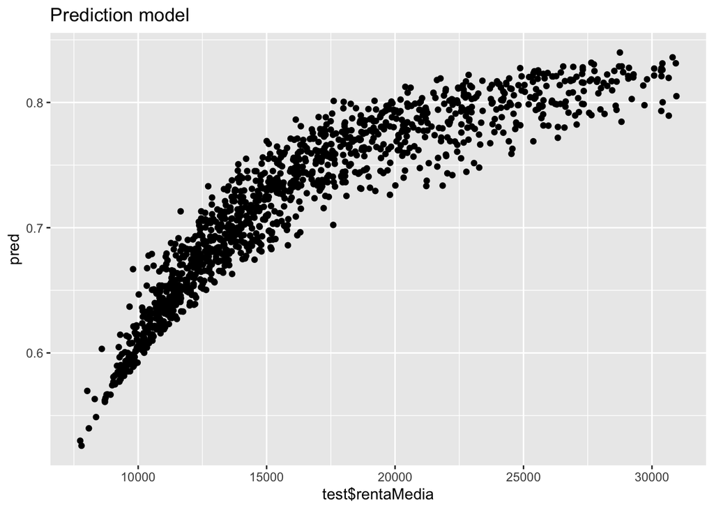

```r
qplot(test$rentaMedia, pred, main="Prediction model")
```

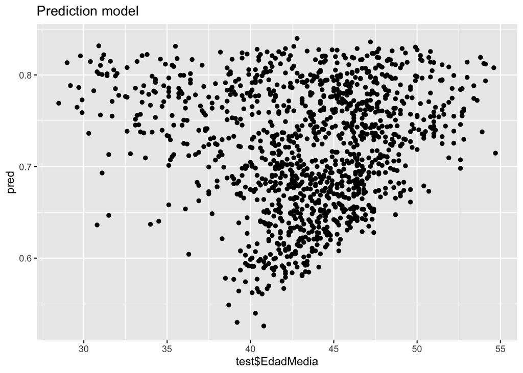

```r
qplot(test$EdadMedia, pred, main="Prediction model")
```

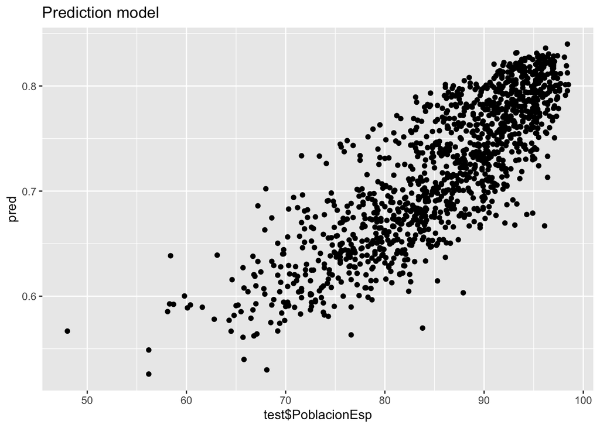

```r
qplot(test$PoblacionEsp, pred, main="Prediction model")
```

Seems to be a good model, still does not seem to be sever overfitting as `train_R2` is not bigger than `test_R2`.

Can we further improve it?

Two ways: adding more information or using better models

### Machine Learning

So far we used linear models with hand-crafted transformations. Next is a short preview of a more flexible supervised learning model that can learn non-linearities automatically. Because of this, we can add more variables related with participation in a non-linear way, like the location of each census section by adding geographic coordinates (longitude/latitude). This is a simple way to let a model capture some spatial patterns.

```r
# centroids for each section
datos.madrid$geom2 = st_centroid(st_geometry(datos.madrid))

# extract long and lat for each centroid
datos.madrid <- datos.madrid %>%
    mutate(long = unlist(map(datos.madrid$geom2,1)),
           lat = unlist(map(datos.madrid$geom2,2)))

# incorporate long and lat into the train and test sets
train = datos.madrid[ind.train,]
test = datos.madrid[-ind.train,]
```

#### A quick preview: decision trees and random forests

A **decision tree** is a model that predicts `Y` by learning a sequence of *if/then* splits on the predictors (e.g., “is income above 15k?”, “is mean age above 45?”, etc.). Trees can capture **non-linearities** and **interactions** automatically, but a single deep tree can overfit.

A **random forest** is an *ensemble* (a collection) of many decision trees trained on slightly different versions of the data. By averaging across many trees, random forests often achieve strong predictive accuracy and reduce overfitting risk compared to a single tree, at the cost of interpretability.

Because `Y` is continuous, here we use a random forest for **regression** (it outputs a predicted turnout rate).

We will treat it as a “black-box predictor” for now. We will study tree-based models and model selection later in the course.

```r
library(randomForest)

set.seed(123)
train_df = sf::st_drop_geometry(train)
test_df = sf::st_drop_geometry(test)

rf.train <- randomForest(total_part ~ rentaMedia + EdadMedia + PoblacionEsp + long + lat, data=train_df, importance=TRUE)
```

Note we do not need to incorporate the non-linearities in the formula, the non-linearities will be captured by the tool

The prediction is the same:

```r
pred <- predict(rf.train, newdata=test_df)

c(train_R2 = rsq(train_df$total_part, predict(rf.train, newdata = train_df)),
  test_R2  = rsq(test_df$total_part, pred))
```

```
##  train_R2   test_R2
## 0.9607272 0.8389297
```

Higher accuracy than before ($R^2$), but the prediction model is completely non linear! Hence, interpretation is more difficult (all the variables are interacting in a non-linear way).

But note the error is between -10% and 10% (in most of the cases), hence a great model with so few variables! However, we got a way better $R^2$ in training than in test, so we are starting to overfit.

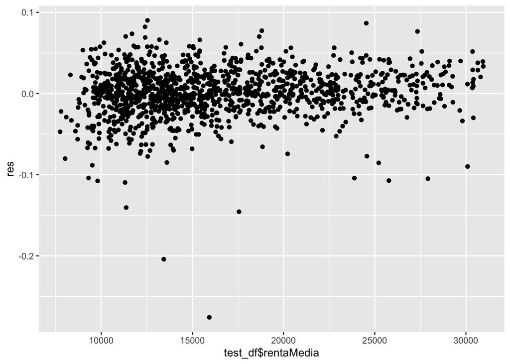

```r
res = test_df$total_part - pred
qplot(test_df$rentaMedia, res)
```

## Interpretability

Even if ML tools are difficult to interpret, there are some helpful tools (see https://christophm.github.io/interpretable-ml-book/)

Two popular “post-hoc” tools (used after fitting the model) are:

- **Variable importance:** which predictors the model relied on the most for accurate predictions.
- **Partial dependence:** how the predicted turnout changes *on average* when we vary one predictor, keeping the others as observed.

These plots are descriptive, not causal: correlated predictors and interactions can make interpretation tricky.

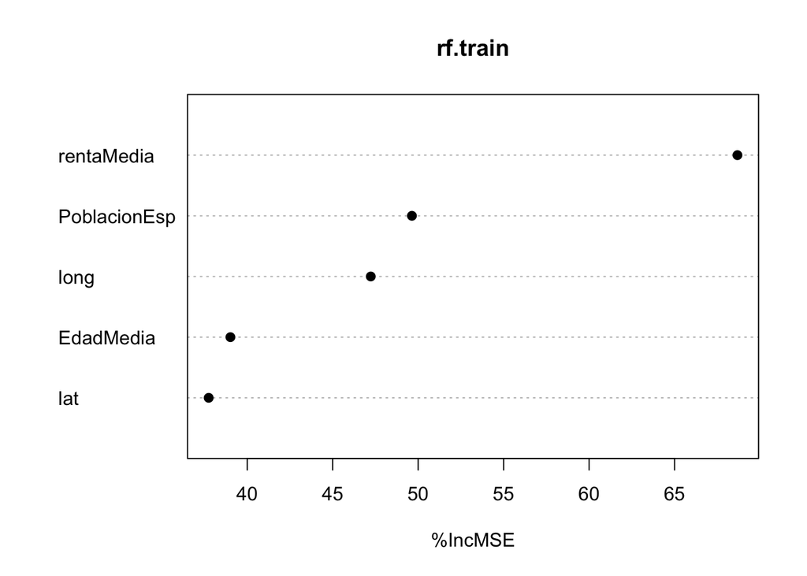

```r
# Dotchart of variable importance as measured by a Random Forest
varImpPlot(rf.train, type=1, pch=19)
```

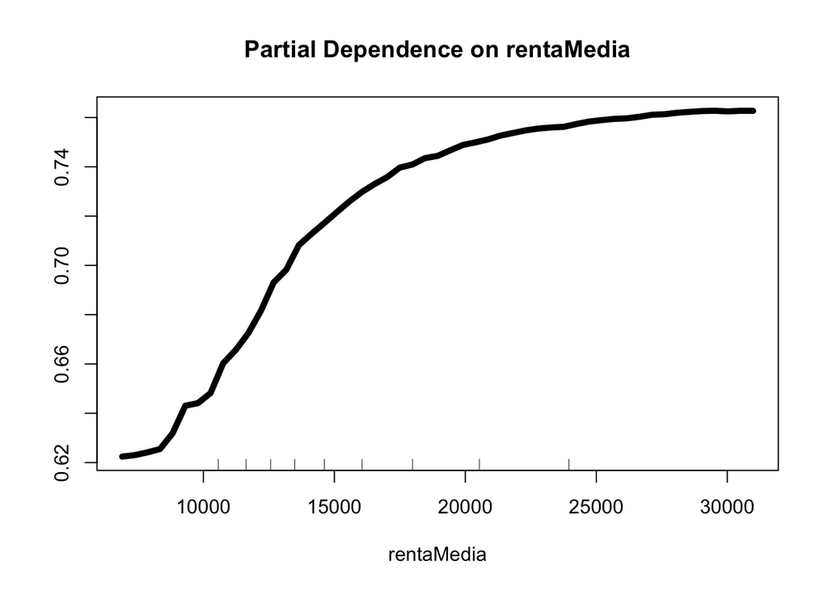

```r
# Partial dependence plots: marginal effect of a predictor on output (participation)
partialPlot(rf.train, train_df, rentaMedia, lwd=5)
```

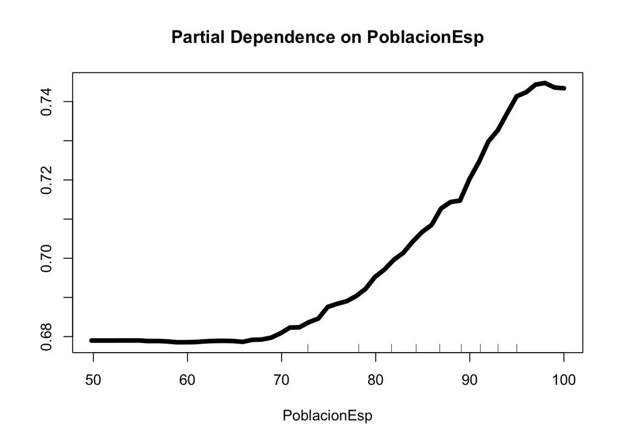

```r
partialPlot(rf.train, train_df, PoblacionEsp, lwd=5)
```

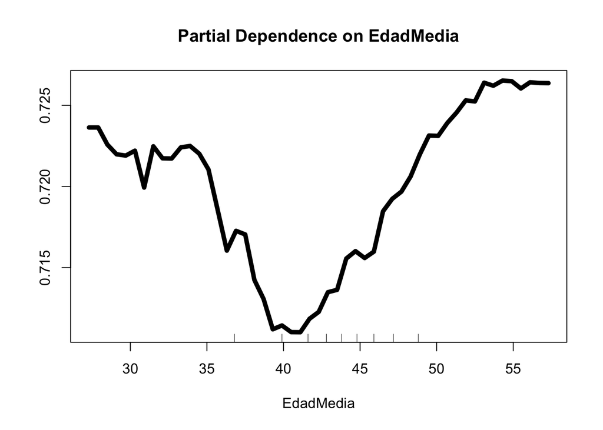

```r
partialPlot(rf.train, train_df, EdadMedia, lwd=5)
```

Insights?

## Conclusions

- Remember: feature engineering is the process of generating features (variables) useful as input for machine-learning tools. The better the input, the better the prediction
- Feature extraction creates new *informative features* from original raw variables
- You need to deal always with outliers and missing values

## Paractice ideas

Extend the previous analysis to get more insights. Some ideas:

- Try other province or CCAA
- Aggregate the dataset by municipalities and check whether the insights are the same after the aggregation
- Besides wealth and age of voters, consider other drivers for participation:

Population by gender: https://www.ine.es/dynt3/inebase/es/index.htm?padre=525

Gini index (income inequality): https://www.ine.es/jaxiT3/Tabla.htm?t=37727&L=0

Education

Family status

Etc.

- Extend the analysis to other countries